# RNASeq

```r
# loading packages
library(tidyverse)
library(kableExtra)
library(ggtext)
library(DESeq2)
library(RColorBrewer)
library(viridis)
library(grid)
library(ggpubr)
library(patchwork)
library(plotly)
library(htmltools)
library(htmlwidgets)
library(tximport)
library(vegan)
library(fgsea)
library(ggh4x)
library(Cairo)
library(lme4)
library(lmerTest)
library(emmeans)
```

## Data Input

All data inputs and outputs in this repo are relative to **FOLDER_PATH**. Please, save the provided data frames in RDS format in the `dataframes` folder.

```r
# Define directory paths based on R.environ
FOLDER_PATH <- Sys.getenv("BOX_PATH_RSVBacPublication")
dataframes_folder <- file.path(FOLDER_PATH, "dataframes")

# Create subfolder for output files
outputs_folder <- file.path(FOLDER_PATH, "outputs/RNASeq")
if (!file.exists(outputs_folder)) {
  dir.create(outputs_folder, recursive = TRUE)
}

Bac.Vir_colors = c("#CC9564", "#a89de0", "#f54590", "#2e67f2", "#856141","#6855c9","#9f2d5e", "#1e439d")
Bac.Vir_fill <- c("white", "white", "white", "white", "#856141","#6855c9","#9f2d5e", "#1e439d")
```

## RNASeq Upstream Analysis

This part of analysis was conducted on the HPC cluster managed by the Biostatistics and Informatics Shared Resource (BISR) and supported by an NCI P30-CA125123 and Institutional funds from the Dan L Duncan Comprehensive Cancer Center and Baylor College of Medicine. Data was transferred to the HPC using `rsync` and **MD5** were verified for all samples to ensure data integrity. The folder `scripts` includes all the scripts used for this part of the analysis.

#### Genome Mapping and Expression Quantification

Gene-level quantification results were imported into R using tximport (Soneson et al., 2015), which produces length-scaled counts and an offset matrix for DESeq2. Transcripts with zero length were corrected to a length of one to avoid computational errors during normalization. We include the resulting txi object in the dataframes folder, as well as metadata, gene annotation and msigdbr, as RDS files for reproducibility.

```r
# Read the provided RDS files
dataframeID <- "RSVbac"
txi <- readRDS(file.path(dataframes_folder, paste0(dataframeID, "_RNASeq_human_txi.rds")))
meta <- readRDS(file.path(dataframes_folder, paste0(dataframeID, "_RNASeq_meta.rds")))
gene_anno <- readRDS(file.path(dataframes_folder, paste0("Homo_sapiens.GRCh38.113.rds")))
msigdbr_human <- readRDS(file.path(dataframes_folder, "Homo_sapiens.msigdbr.2025.1.Hs.rds"))
```

#### Saturation Curves

Rarefaction curves were generated using the [**vegan**](https://vegandevs.github.io/vegan/) (Oksanen et al., 2024) package to confirm that sequencing depth was sufficient to capture the majority of expressed genes. Subsets of the reads in a sample are taken and the number of detected genes in each of these subsets is plotted.

```r
make_rarefaction_plot <- function(txi) {

  # Prepare count matrix
  df_counts_matrix <- round(txi$counts)
  raremax <- round(min(rowSums(t(df_counts_matrix))), 0)

  # Generate rarefaction data
  rarefy_df <- rarecurve(
    t(df_counts_matrix),
    step = round(raremax / 10, 0),
    sample = raremax,
    tidy = TRUE
  )

  # Clean up metadata and separate identifiers
  rarefy_df <- rarefy_df %>%
    mutate(Site = gsub("\\s*\\|\\s*", "|", Site)) %>%
    separate(Site, into = c("species", "virus", "line", "exp"), sep = "\\|", remove = FALSE) %>%
    mutate(
      virus = factor(virus),
      line = factor(line),
      species = factor(species, levels = c("NB", "Spn", "Hin", "Dpi"))
    )

  # Make plot
  plot_rarefy <- ggplot(rarefy_df, aes(
    x = Sample, y = Species,
    color = interaction(species, virus, sep = " "),
    shape = interaction(line, exp, sep = " ", lex.order = TRUE)
  )) +
    geom_point(size = 1.5) +
    scale_shape_manual(values = c(1, 2, 15, 16, 17)) +
    scale_color_manual(values = Bac.Vir_colors) +
    labs(x = "reads", y = "genes", color = "Sample", shape = "Exp") +
    scale_y_continuous(expand = c(0, 0), limits = c(0, max(rarefy_df$Species) * 1.02)) +
    theme_bw(base_size = 14) +
    theme(
      axis.text.x = element_text(angle = 30, hjust = 1),
      panel.grid.major = element_blank(),
      panel.grid.minor = element_blank(),
      plot.margin = margin(t = 15, r = 0, b = -18, l = 0)
    )

  return(plot_rarefy)
}
```

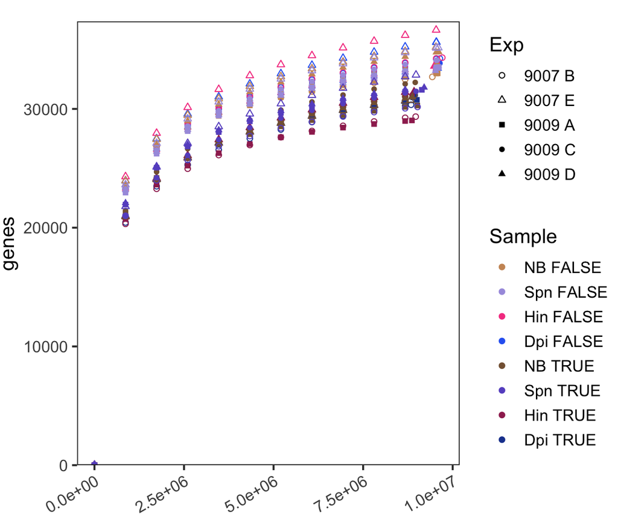

```r
make_rarefaction_plot(txi)
```

This analysis confirmed adequate sequencing depth. We therefore proceeded to quality assessment and normalization of the gene expression data.

## Exploratory DESeq Analysis

An initial model was fit for normalization and quality assessment only. We use it to explore the data and identify possible batch effects due to sequencing the data in two independent runs, without considering any interaction between variables. The final model for differential expression analysis is described in the next section.

```r
# DESeq design
dds_exp <- DESeqDataSetFromTximport(txi,
                                colData = meta,
                                design = ~ species + virus + line + seq_run)

# Run DESeq
dds_exp <- DESeq(dds_exp)

# See design
design(dds_exp)
```

```
~species + virus + line + seq_run
```

We performed an unbiased (blind = TRUE, independent of the dds design formula) transformation of the data for exploratory analysis, calculated based on variance stabilizing transformations (VST) (Anders and Huber, 2010; Huber et al., 2003; Tibshirani, 1988). Principal component analysis was performed on the VST data using the top 500 genes by variance to assess the primary sources of variation and evaluate potential batch effects.

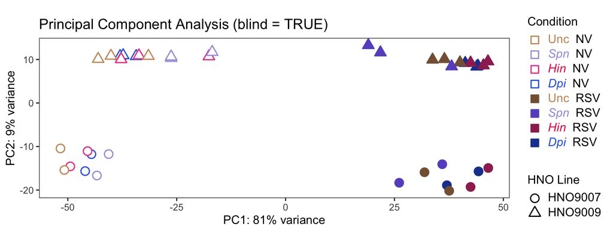

```r
vsd_exp <- vst(dds_exp, blind = TRUE)
pcaData <- plotPCA(vsd_exp, intgroup = c("species", "virus", "line", "seq_run"), returnData = TRUE) %>%
  mutate(line = paste0("HNO", line))
percentVar <- round(100 * attr(pcaData, "percentVar"))

pPCA <- ggplot(pcaData, aes(PC1, PC2)) +
  geom_point(aes(fill = Bac.Vir_label, color = Bac.Vir_label, shape = line),
             size = 4, stroke = 1) +
  scale_shape_manual(values = c(21, 24)) +
  scale_color_manual(values = Bac.Vir_colors) +
  scale_fill_manual(values = Bac.Vir_fill) +
  ggtitle("Principal Component Analysis (blind = TRUE)") +
  xlab(paste0("PC1: ", percentVar[1], "% variance")) +
  ylab(paste0("PC2: ", percentVar[2], "% variance")) +
  labs(fill = "Condition", color = "Condition", shape = "HNO Line") +
  theme_bw(base_size = 14) +
  theme(
    panel.grid.major = element_blank(),
    panel.grid.minor = element_blank(),
    legend.text = element_markdown(size = 14),
  ) +
    guides(
    color = guide_legend(title = "Condition", override.aes = list(color = Bac.Vir_colors, shape = 22))
  ) + coord_fixed()

pPCA
```

```r
# Save PCA plot
saveRDS(pPCA, file = file.path(outputs_folder, "RSVbac_RNASeq_human_PCA.rds"))
```

Samples from different sequencing runs and experimental dates were interspersed rather than clustered, indicating negligible batch effects.

## DGE virus * species

Based on the exploratory analysis, we decided to exclude `seq_run` and `exp` from the final DESeq2 model, as they did not contribute significantly to the observed variation.

When using `DESeqDataSetFromTximport()`, tximport helps generate an offset to correct for differences in average transcript length across samples. This adjustment accounts for potential bias introduced by differential transcript usage (DTU), ensuring that gene-level differential expression analysis remains accurate.

```r
# DESeq design
dds <- DESeqDataSetFromTximport(txi,
                                colData = meta,
                                design = ~ virus + species + virus:species + line)
```

The Ensembl annotation gets added to the dds for follow up plots and tables.

```r
# Convert rowData(dds) to a data frame for merging
rowdata_df <- as.data.frame(rowData(dds))

# Add rownames as a new column in the dataframe
rowdata_df$ensembl_gene_id <- rownames(rowdata_df)

# Merge with rowData(dds)
rowdata_df <- left_join(rowdata_df, gene_anno, by = "ensembl_gene_id")

# Assign back to dds
rowData(dds) <- DataFrame(rowdata_df, row.names = rowdata_df$ensembl_gene_id)

# Check if the row names of dds and rowData are still correctly aligned
#all(rownames(dds) == rownames(rowData(dds))) # Should return TRUE if correct
```

This design captures all the biological variables of interest:

```r
# Run DESeq
dds <- DESeq(dds)

# See results names design
design(dds)
```

```
~virus + species + virus:species + line
```

```r
#resultsNames(dds)
```

- **virus + species + virus:species** Includes main effects of virus and species, as well as their interaction. This allows us to test whether the effect of virus depends on the species. This is equivalent to **virus * species**.
- **line** Models differences between the two organoid lines.

We apply a variance stabilizing transformation using `vst()` from the **DESeq2** package. This transformation makes the variance roughly independent of the mean, which is especially useful for PCA and clustering. It produces log2-like values that are more homoscedastic than raw or normalized counts.

```r
# Run VST
vst_matrix <- vst(dds)

# Save as assay in dds
assays(dds)[["vst"]] <- assay(vst_matrix)

vst_matrix <- assays(dds)[["vst"]]

saveRDS(vst_matrix, file = file.path(outputs_folder, paste0(dataframeID, "_RNASeq_vst_matrix.rds")))
```

### Contrasts Results

We implemented the adaptive shrinkage method (ashr(Stephens, 2016)) to obtain more accurate and stable estimates of log₂ fold changes (LFC) for each gene across contrasts. This approach mitigates the impact of low counts and high variability, which can otherwise lead to exaggerated LFC estimates. Shrinkage was performed using the `lfcShrink()` function from the **DESeq2** package.

```r
# Function to run a contrast analysis and generate plots
run_contrast_analysis <- function(dds, FC_cutoff, contrast_name,
                                 contrast = NULL, coef = NULL,
                                 ylim = NULL, show_outlier = TRUE) {
  # Check inputs
  if (!is.null(contrast)) {
    res <- results(dds, contrast = contrast, alpha = 0.05)
    resLFC <- lfcShrink(dds, contrast = contrast, type = "ashr")
  } else if (!is.null(coef)) {
    res <- results(dds, name = coef, alpha = 0.05)
    resLFC <- lfcShrink(dds, coef = coef, type = "ashr")
  } else {
    stop("Please provide either a 'contrast' or a 'coef'.")
  }

  # Results table
  res_df <- as.data.frame(res)
  res_df$Geneid <- rownames(res_df)
  res_df$contrast <- contrast_name
  res_df$log2FoldChange_shrunk <- resLFC$log2FoldChange

  # Merge with gene annotation (adds hgnc_symbol, etc.)
  res_df <- left_join(res_df, gene_anno, by = c("Geneid" = "ensembl_gene_id"))
  rownames(res_df) <- NULL

  # Make label: Symbol (Geneid) + stats
  res_df <- res_df %>%
    mutate(symbol = ifelse(!is.na(hgnc_symbol) & hgnc_symbol != "",
                           hgnc_symbol, Geneid))

  # Determine ylim if not provided
  if (is.null(ylim)) {
    ylim_val <- quantile(abs(res_df$log2FoldChange_shrunk), 0.99, na.rm = TRUE)
    ylim <- c(-ylim_val, ylim_val)
  }

  # Identify significant genes and outliers for plotting
  res_df <- res_df %>%
    filter(!is.na(baseMean), !is.na(log2FoldChange_shrunk)) %>%
    mutate(
      sig_category = case_when(
        is.na(padj) ~ "No-pvalue",
        padj > 0.05 ~ "p-value >0.05",
        padj <= 0.05 & abs(log2FoldChange_shrunk) <= 0 ~ "p-value <0.05",
        padj <= 0.05 & log2FoldChange_shrunk > 0 ~ "Up",
        padj <= 0.05 & log2FoldChange_shrunk < -0 ~ "Down"
      ),
      sig_category = factor(sig_category, levels = c("No-pvalue","p-value >0.05","p-value <0.05","Up","Down")),
      is_outlier = log2FoldChange_shrunk < ylim[1] | log2FoldChange_shrunk > ylim[2],
      log2FoldChange_shrunk_clipped = case_when(
        log2FoldChange_shrunk < ylim[1] ~ ylim[1] * 0.98,  # Slightly inside boundary
        log2FoldChange_shrunk > ylim[2] ~ ylim[2] * 0.98,
        TRUE ~ log2FoldChange_shrunk
      ),
      point_shape = if_else(is_outlier & show_outlier, 18, 16)
    ) %>%
    select(Geneid, contrast, everything())

# Create custom MA plot (ggplot version)
  ma_plot <- ggplot(res_df, aes(x = log2(baseMean),
                         y = if_else(is_outlier & show_outlier,
                                     log2FoldChange_shrunk_clipped,
                                     log2FoldChange_shrunk))) +
    geom_point(aes(color = sig_category, shape = point_shape),
               size = 1, alpha = 0.6) +
    scale_shape_identity() +
    geom_hline(yintercept = 0, linetype = "solid", color = "black", linewidth = 0.3) +
    geom_hline(yintercept = c(-FC_cutoff, FC_cutoff),
               linetype = "dashed", linewidth = 0.5) +
    scale_color_manual(
      values = c("Up" = "salmon3", "Down" = "salmon3",
                 "No-pvalue" = "gray60", "p-value >0.05" = "gray40", "p-value <0.05" = "salmon3"),
      name = ""
    ) +
    coord_cartesian(ylim = ylim) +
    labs(
      title = contrast_name,
      x = "log2(mean expression)",
      y = "Shrunken log2FC"
    ) +
    theme_bw(base_size = 10) +
    theme(
      panel.grid.major = element_blank(),
      panel.grid.minor = element_blank(),
      plot.title = element_text(hjust = 0.5, size = 11, face = "bold"),
      legend.position = "none"
    )

  # Volcano plot (ggplot)
  volcano_plot <- ggplot(res_df, aes(x = log2FoldChange_shrunk, y = -log10(padj))) +
    geom_point(aes(color = sig_category), size = 1, alpha = 0.6) +
    scale_color_manual(
      values = c("Up" = "salmon3", "Down" = "salmon3",
                 "No-pvalue" = "gray60", "p-value >0.05" = "gray40", "p-value <0.05" = "salmon3"),
      name = ""
    ) +
    geom_vline(xintercept = c(-FC_cutoff, FC_cutoff), linetype = "dashed") +
    geom_hline(yintercept = -log10(0.05), linetype = "dashed") +
    labs(title = contrast_name,
         x = "Shrunken log2FC",
         y = "-log10(adjusted p-value)") +
    theme_bw(base_size = 10) +
    theme(
      panel.grid.major = element_blank(),
      panel.grid.minor = element_blank(),
      plot.title = element_text(hjust = 0.5, size = 11, face = "bold"),
      legend.position = "none"
    )

  return(list(
    results = res_df,
    ma_plot = ma_plot,
    volcano_plot = volcano_plot
  ))
}
```

```r
# Create output folder for individual contrasts results
contrasts_folder <- file.path(outputs_folder, "Contrasts_individual_results")

if (!dir.exists(contrasts_folder)) {
  dir.create(contrasts_folder, recursive = TRUE)
}
```

#### Virus TRUE vs FALSE in each Species

This section tests the effect of virus infection (TRUE vs FALSE) within each bacterial species specifically:

- For the reference species NB, the virus effect is captured by the main coefficient `virus_TRUE_vs_FALSE`.
- For other species (Dpi, Spn, Hin), the virus effect is a combination of the main virus effect plus the interaction term (e.g., `virusTRUE.speciesDpi`).

```r
# Define contrast list with full virus effect per species:
contrast_Virus_TvsF <- list(
  VirusTvsF_NB  = "virus_TRUE_vs_FALSE",                                   # virus effect in NB, does not need interaction
  VirusTvsF_Spn = list(c("virus_TRUE_vs_FALSE", "virusTRUE.speciesSpn")),  # virus effect in Spn
  VirusTvsF_Hin = list(c("virus_TRUE_vs_FALSE", "virusTRUE.speciesHin")),   # virus effect in Hin
  VirusTvsF_Dpi = list(c("virus_TRUE_vs_FALSE", "virusTRUE.speciesDpi"))  # virus effect in Dpi
)

# Run contrasts
res_Virus_TvsF <- imap(contrast_Virus_TvsF, function(contrast_val, name) {
  if (is.character(contrast_val)) {
    run_contrast_analysis(dds, FC_cutoff = 2, contrast_name = name, coef = contrast_val, ylim = c(-5, 5))
  } else {
    run_contrast_analysis(dds, FC_cutoff = 2, contrast_name = name, contrast = contrast_val, ylim = c(-5, 5))
  }
})

# Save individual contrast results R file
for (contrast_name in names(res_Virus_TvsF)) {
  saveRDS(res_Virus_TvsF[[contrast_name]],
          file = file.path(contrasts_folder, paste0("DESeq2_contrast_", contrast_name, ".rds")))
}

# Summarize table based on sig_category for each contrast
summary_Virus_TvsF <- map_dfr(res_Virus_TvsF,
                                           ~ .x$results %>%
                                             group_by(sig_category) %>%
                                             summarise(count = n()) %>%
                                             pivot_wider(names_from = sig_category, values_from = count) %>%
                                             mutate_all(~ replace(., is.na(.), 0)),
                                           .id = "contrast")

kable(summary_Virus_TvsF)
```

| contrast | No-pvalue | p-value >0.05 | Up | Down |
| --- | --- | --- | --- | --- |
| VirusTvsF_NB | 46313 | 19780 | 5841 | 6998 |
| VirusTvsF_Spn | 48363 | 22313 | 3931 | 4325 |
| VirusTvsF_Hin | 45288 | 20352 | 5941 | 7351 |
| VirusTvsF_Dpi | 46313 | 20083 | 5612 | 6924 |

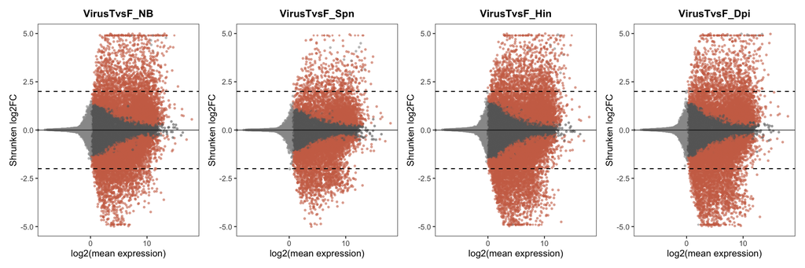

```r
wrap_plots(map(res_Virus_TvsF, "ma_plot"), nrow = 1)
```

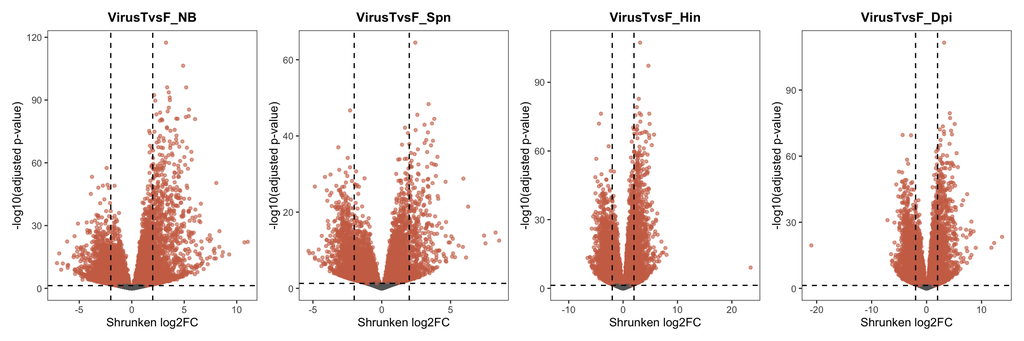

```r
wrap_plots(map(res_Virus_TvsF, "volcano_plot"), nrow = 1)
```

#### Difference in Virus Effect Compared to NB

Here we focus on whether the virus effect differs between each species and the reference species NB. This highlights species-specific modulation of virus response by comparing the virus effect in each species against the baseline virus effect in NB.

- We use the interaction terms alone (e.g., `virusTRUE.speciesDpi`), which quantify how much the virus effect in each species deviates from that in NB.

```r
# Define contrast list of interaction terms (difference in virus effect compared to NB, interaction terms only)
contrast_VirusEffect_diff_vsNB <- list(
  VirusEffectDiff_Spn = "virusTRUE.speciesSpn",
  VirusEffectDiff_Hin = "virusTRUE.speciesHin",
  VirusEffectDiff_Dpi = "virusTRUE.speciesDpi"
)

# Run contrasts using coef names (interaction terms)
res_VirusEffect_diff_vsNB <- imap(contrast_VirusEffect_diff_vsNB,
                                  ~ run_contrast_analysis(dds, FC_cutoff = 2, contrast_name = .y, coef = .x, ylim = c(-3, 3)))

# Save individual contrast results R file
for (contrast_name in names(res_VirusEffect_diff_vsNB)) {
  saveRDS(res_VirusEffect_diff_vsNB[[contrast_name]],
          file = file.path(contrasts_folder, paste0("DESeq2_contrast_", contrast_name, ".rds")))
}

# Summarize table based on sig_category for each contrast
summary_VirusEffect_diff_vsNB <- map_dfr(res_VirusEffect_diff_vsNB,
                                           ~ .x$results %>%
                                             group_by(sig_category) %>%
                                             summarise(count = n()) %>%
                                             pivot_wider(names_from = sig_category, values_from = count) %>%
                                             mutate_all(~ replace(., is.na(.), 0)),
                                           .id = "contrast")

kable(summary_VirusEffect_diff_vsNB)
```

| contrast | No-pvalue | p-value >0.05 | Up | Down |
| --- | --- | --- | --- | --- |
| VirusEffectDiff_Spn | 58602 | 18705 | 597 | 1028 |
| VirusEffectDiff_Hin | 54504 | 24399 | 6 | 23 |
| VirusEffectDiff_Dpi | 61676 | 17059 | 36 | 161 |

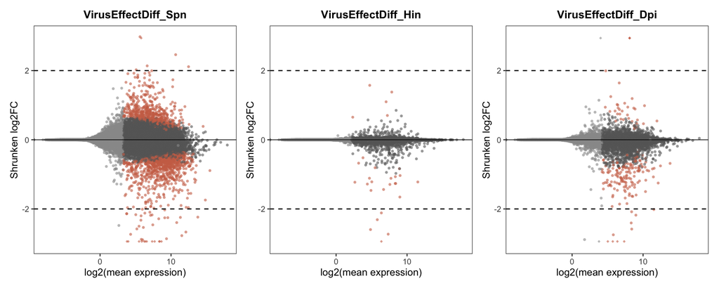

```r
wrap_plots(map(res_VirusEffect_diff_vsNB, "ma_plot"), nrow = 1)
```

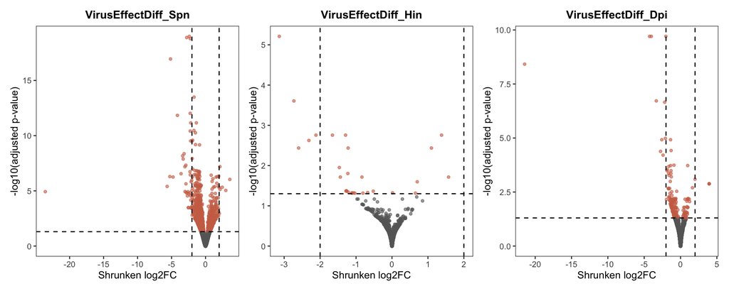

```r
wrap_plots(map(res_VirusEffect_diff_vsNB, "volcano_plot"), nrow = 1)
```

#### Bacteria vs NB in Virus FALSE

This comparison evaluates how each bacterial species differs from the reference species NB when virus is absent (`virus = FALSE`). This reveals baseline species-specific gene expression differences without virus influence.

- Because virus FALSE is the baseline in the model, these contrasts use only the main species effects (e.g., `species_Dpi_vs_NB`).

```r
# These don't need the interaction term because virus FALSE is the baseline
contrast_Species_vsNB_VF <- list(
  SpnvsNB_VF = "species_Spn_vs_NB",
  HinvsNB_VF = "species_Hin_vs_NB",
  DpivsNB_VF = "species_Dpi_vs_NB"
)

# Run all contrasts and generate plots
res_Species_vsNB_VF <- imap(contrast_Species_vsNB_VF,
                            ~ run_contrast_analysis(dds, FC_cutoff = 2, contrast_name = .y, coef = .x, ylim = c(-3, 3)))

# Save individual contrast results R file
for (contrast_name in names(res_Species_vsNB_VF)) {
  saveRDS(res_Species_vsNB_VF[[contrast_name]],
          file = file.path(contrasts_folder, paste0("DESeq2_contrast_", contrast_name, ".rds")))
}

# Summarize table based on sig_category for each contrast
summary_Species_vsNB_VF <- map_dfr(res_Species_vsNB_VF,
                                   ~ .x$results %>%
                                     group_by(sig_category) %>%
                                     summarise(count = n()) %>%
                                     pivot_wider(names_from = sig_category, values_from = count) %>%
                                     mutate_all(~ replace(., is.na(.), 0)),
                                   .id = "contrast")
kable(summary_Species_vsNB_VF)
```

| contrast | No-pvalue | p-value >0.05 | Up | Down |
| --- | --- | --- | --- | --- |
| SpnvsNB_VF | 54504 | 24030 | 328 | 70 |
| HinvsNB_VF | 47338 | 31513 | 80 | 1 |
| DpivsNB_VF | 49386 | 29443 | 97 | 6 |

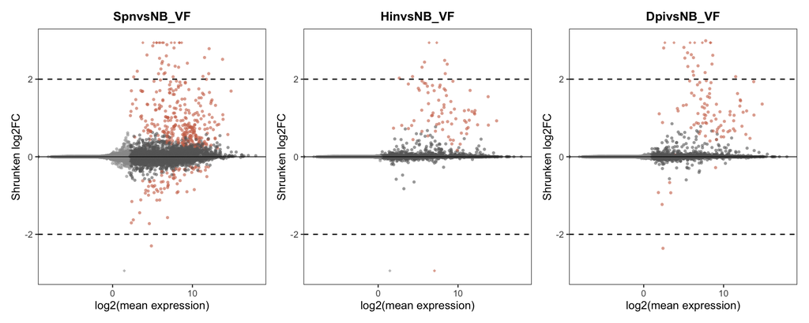

```r
wrap_plots(map(res_Species_vsNB_VF, "ma_plot"), nrow = 1)
```

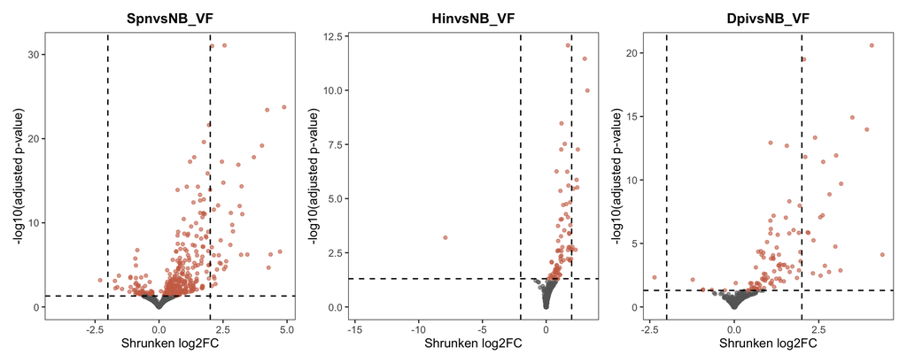

```r
wrap_plots(map(res_Species_vsNB_VF, "volcano_plot"), nrow = 1)
```

#### Bacteria vs NB in Virus TRUE

Here we test the species differences under virus infection (virus = TRUE). This reveals species-specific gene expression differences that happens under virus influence.

- These contrasts combine the main species effect plus the interaction with virus (e.g., `species_Dpi_vs_NB` + `virusTRUE.speciesDpi`).

```r
# These include the interaction terms to reflect virus-specific responses
contrast_Species_vsNB_VT <- list(
  SpnvsNB_VT = list(c("species_Spn_vs_NB", "virusTRUE.speciesSpn")),
  HinvsNB_VT = list(c("species_Hin_vs_NB", "virusTRUE.speciesHin")),
  DpivsNB_VT = list(c("species_Dpi_vs_NB", "virusTRUE.speciesDpi"))
)

# Run all contrasts and generate plots
res_Species_vsNB_VT <- imap(contrast_Species_vsNB_VT,
                            ~ run_contrast_analysis(dds, FC_cutoff = 2, contrast_name = .y, contrast = .x, ylim = c(-3, 3)))

# Save individual contrast results R file
for (contrast_name in names(res_Species_vsNB_VT)) {
  saveRDS(res_Species_vsNB_VT[[contrast_name]],
          file = file.path(contrasts_folder, paste0("DESeq2_contrast_", contrast_name, ".rds")))
}

# Summarize table based on sig_category for each contrast
summary_Species_vsNB_VT <- map_dfr(res_Species_vsNB_VT,
                                   ~ .x$results %>%
                                     group_by(sig_category) %>%
                                     summarise(count = n()) %>%
                                     pivot_wider(names_from = sig_category, values_from = count) %>%
                                     mutate_all(~ replace(., is.na(.), 0)),
                                   .id = "contrast")
kable(summary_Species_vsNB_VT)
```

| contrast | No-pvalue | p-value >0.05 | Up | Down |
| --- | --- | --- | --- | --- |
| SpnvsNB_VT | 58602 | 17814 | 1089 | 1427 |
| HinvsNB_VT | 60651 | 17855 | 121 | 305 |
| DpivsNB_VT | 57578 | 20495 | 244 | 615 |

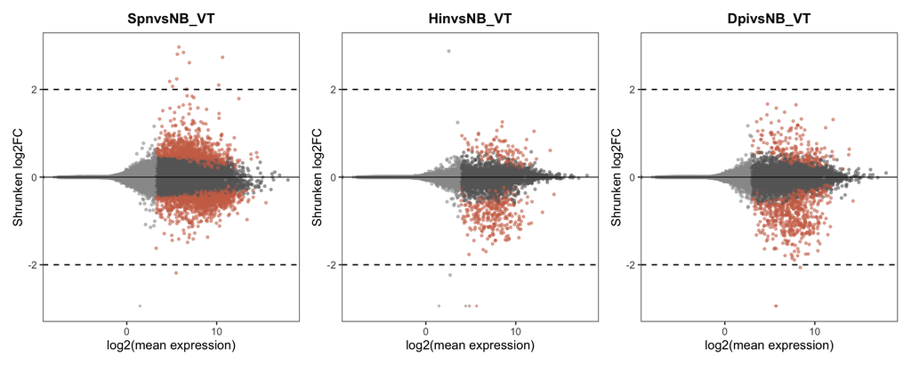

```r
wrap_plots(map(res_Species_vsNB_VT, "ma_plot"), nrow = 1)
```

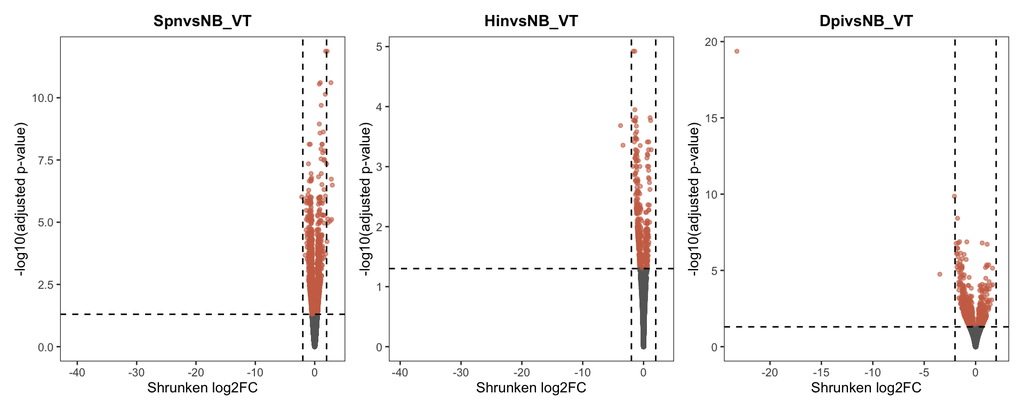

```r
wrap_plots(map(res_Species_vsNB_VT, "volcano_plot"), nrow = 1)
```

#### Line (9009 vs 9007)

This section examines the effect of HNO line on gene expression, independent of species and virus status. This contrast helps identify baseline donor-specific transcriptional differences, which may reflect biological variation.

- In this setup, 9007 is the reference, and the coefficient `line_9009_vs_9007` captures the log2 fold change in gene expression for line 9009 relative to line 9007, averaged across all species and virus conditions.

```r
res_Line_9009vs9007 <- run_contrast_analysis(dds, FC_cutoff = 2, ylim = c(-5, 5),
  contrast_name = "Line_9009_vs_9007",
  coef = "line_9009_vs_9007")

# Save individual contrast results R file
saveRDS(res_Line_9009vs9007,
        file = file.path(contrasts_folder, "DESeq2_contrast_Line_9009_vs_9007.rds"))

# Summarize table based on sig_category for the contrast
summary_Line_9009vs9007 <- res_Line_9009vs9007$results %>%
  group_by(sig_category) %>%
  summarise(count = n()) %>%
  pivot_wider(names_from = sig_category, values_from = count) %>%
  mutate_all(~ replace(., is.na(.), 0))
kable(summary_Line_9009vs9007)
```

| No-pvalue | p-value >0.05 | Up | Down |
| --- | --- | --- | --- |
| 45288 | 24853 | 4221 | 4570 |

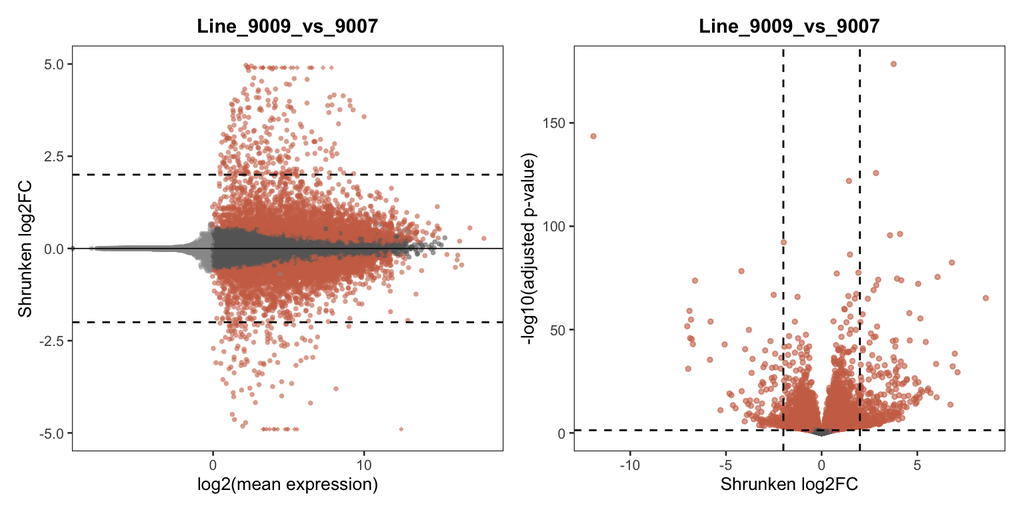

```r
#figures side by side
wrap_plots(
  res_Line_9009vs9007$ma_plot,
  res_Line_9009vs9007$volcano_plot,
  nrow = 1
)
```

### Combine all contrast results

```r
# Flatten and combine all contrast result objects into one table
all_contrast_results <- list(
  res_Virus_TvsF,
  res_VirusEffect_diff_vsNB,
  res_Species_vsNB_VF,
  res_Species_vsNB_VT,
  list(Line_9009vs9007 = res_Line_9009vs9007)) %>% flatten()

# Build a single DE table
DESeqData <- map_dfr(all_contrast_results, "results") %>%
  select(Geneid, contrast, everything()) %>%
  select(1:match("sig_category", names(.)))

# Save the results
write.csv(DESeqData, file = file.path(outputs_folder, "RSVbac_DESeq_human_Contrasts.csv"), row.names = FALSE)
saveRDS(DESeqData, file = file.path(outputs_folder, "RSVbac_DESeq_human_Contrasts.rds"))

saveRDS(dds, file = file.path(outputs_folder, "RSVbac_DESeq_human_dds.rds"))
```

## GSEA

The original **Gene Set Enrichment Analysis (GSEA)** (Subramanian et al., 2005) method ranks genes by expression changes and tests for enrichment of predefined gene sets using a weighted Kolmogorov–Smirnov-like statistic. Here we use Fast Gene Set Enrichment Analysis (**fgsea**) (Korotkevich et al., 2016), specifically the `fgseaMultilevel()` function, based on an adaptive multilevel Monte Carlo algorithm that drastically reduces runtime. This allows us to estimate arbitrarily low p-values (e.g., as small as 10⁻¹⁰⁰), enabling standard multiple testing corrections like Benjamini-Hochberg.

```r
# Function to Run GSEA on a single contrast using Ensembl gene IDs
run_fgsea <- function(contrasts_df, each_contrast, msigdb, collection, subcollection = NULL) {
  # Build Ensembl-based rank vector from the selected contrast table
  ranks <- contrasts_df %>%
    filter(contrast == each_contrast) %>%
    filter(!is.na(stat))
  ranks_vec <- setNames(ranks$stat, ranks$Geneid)

  # Filter the msigdb collection and convert to pathways list
  msig_sub <- msigdb %>%
    { if (!is.null(subcollection)) {
        filter(., gs_collection == collection, gs_subcollection == subcollection)
      } else {
        filter(., gs_collection == collection)
      }
    } %>%
    dplyr::select(gs_name, ensembl_gene) %>%
    filter(!is.na(ensembl_gene), ensembl_gene != "") %>%
    distinct()

  if (nrow(msig_sub) == 0L) {
    stop("No gene sets found for collection = ", collection,
         if (!is.null(subcollection)) paste0(", subcollection = ", subcollection) else "")
  }

  pathways <- split(msig_sub$ensembl_gene, msig_sub$gs_name)

  # Run fgsea (multilevel for accurate small p-values)
  fgseaRes <- fgseaMultilevel(pathways = pathways, stats = ranks_vec) %>%
    arrange(padj, pval)

  return(list(
    pathways = pathways,
    fgseaRes = fgseaRes)
  )
}

# Function to run GSEA on multiple contrasts and extract filtered NES matrix
run_multi_contrast_gsea <- function(contrasts_df, contrasts_list, msigdb, collection, subcollection = NULL,
                                    padj_threshold = 0.05, nes_threshold = NULL) {

  # Run GSEA on each contrast using the standalone run_fgsea function
  fgsea_results <- map(
    contrasts_list %>% set_names(),
    ~ {
      run_fgsea(
        contrasts_df = contrasts_df,
        each_contrast = .x,
        msigdb = msigdb,
        collection = collection,
        subcollection = subcollection
      )
    }
  )

  # Extract results from each contrast into a single dataframe
  nes_df <- map_dfr(
    names(fgsea_results),
    ~ {
      fgsea_results[[.x]]$fgseaRes %>%
        as_tibble() %>%
        dplyr::select(pathway, NES, padj) %>%
        mutate(contrast = .x)
    }
  ) %>%
    mutate(pathway = str_remove(pathway, "^[^_]+_"))

  # Find pathways that meet significance threshold in at least one contrast
  sig_pathways <- nes_df %>%
    filter(padj < padj_threshold) %>%
    pull(pathway) %>%
    unique()

  # Additionally filter by NES threshold if provided
  # Keep pathways where absolute NES exceeds threshold in at least one contrast
  if (!is.null(nes_threshold)) {
    nes_filtered_pathways <- nes_df %>%
      filter(abs(NES) >= nes_threshold) %>%
      pull(pathway) %>%
      unique()

    # Take intersection: must meet BOTH padj AND NES criteria
    sig_pathways <- intersect(sig_pathways, nes_filtered_pathways)
  }

  # Create NES matrix for selected pathways
  nes_matrix <- nes_df %>%
    filter(pathway %in% sig_pathways) %>%
    dplyr::select(pathway, contrast, NES) %>%
    pivot_wider(names_from = contrast, values_from = NES, values_fill = 0) %>%
    column_to_rownames("pathway") %>%
    as.matrix()

  # Create padj matrix for significance annotation
  padj_matrix <- nes_df %>%
    filter(pathway %in% sig_pathways) %>%
    dplyr::select(pathway, contrast, padj) %>%
    pivot_wider(names_from = contrast, values_from = padj, values_fill = 1) %>%
    column_to_rownames("pathway") %>%
    as.matrix()

  # Sort pathways by their range (max variation across contrasts)
  # This puts the most dynamically regulated pathways at the top
  nes_range <- apply(nes_matrix, 1, function(x) max(x) - min(x))
  sort_order <- order(nes_range, decreasing = TRUE)

  nes_matrix <- nes_matrix[sort_order, , drop = FALSE]
  padj_matrix <- padj_matrix[sort_order, , drop = FALSE]

  # Return both raw results and filtered matrices
  return(list(
    raw_fgsea = fgsea_results,
    nes_matrix = nes_matrix,
    padj_matrix = padj_matrix,
    combined_df = nes_df,
    sig_pathways = sig_pathways
  ))
}

# Function to create grouped heatmaps of NES values with significance annotations
plot_fgsea_grouped_ggplot <- function(multi_contrast_gsea_res, pathway_groups, category_colors,
                                      padj_threshold = 0.05, title = "GSEA NES Heatmap (Grouped)",
                                      nicknames = NULL) {

  # Extract matrices
  nes_matrix <- multi_contrast_gsea_res$nes_matrix
  padj_matrix <- multi_contrast_gsea_res$padj_matrix

  # Apply nicknames if provided
  if (!is.null(nicknames)) {
    colnames(nes_matrix) <- nicknames[colnames(nes_matrix)]
    colnames(padj_matrix) <- nicknames[colnames(padj_matrix)]
  }

  # Convert to long format
  nes_df <- as.data.frame(nes_matrix) %>%
    rownames_to_column("pathway") %>%
    pivot_longer(-pathway, names_to = "contrast", values_to = "NES")

  padj_df <- as.data.frame(padj_matrix) %>%
    rownames_to_column("pathway") %>%
    pivot_longer(-pathway, names_to = "contrast", values_to = "padj")

  # Merge NES and padj
  plot_df <- nes_df %>%
    left_join(padj_df, by = c("pathway", "contrast")) %>%
    left_join(pathway_groups, by = "pathway")

  # Set factor levels for consistent ordering
  plot_df$category <- factor(plot_df$category, levels = unique(pathway_groups$category))
  plot_df$contrast <- factor(plot_df$contrast, levels = colnames(nes_matrix))

  # Significance stars
  plot_df$star <- ifelse(plot_df$padj < padj_threshold, "*", "")

  # Plot
  ggplot(plot_df, aes(x = contrast, y = pathway, fill = NES)) +
    geom_tile(color = "white") +
    geom_text(aes(label = star), color = "black", size = 6, vjust = 0.75) +
    facet_grid2(category ~ ., scales = "free_y", space = "free_y", switch = "y",
                strip = strip_themed(background_y = elem_list_rect(fill = category_colors))) +
    scale_y_discrete(expand = c(0,0), position = "right") +
    scale_x_discrete(expand = c(0,0)) +
    scale_fill_gradientn(colours = c("#009AD1", "#d9f1fa", "#fefbea", "#fae1e4", "#AD1457"),
                         rescaler = ~ scales::rescale_mid(.x, mid = 0)) +
    labs(x = "", y = "") +
    theme_bw(base_size = 12) +
    theme(
      panel.grid.major = element_blank(),
      panel.grid.minor = element_blank(),
      strip.text.y.left = element_text(size = 12, face = "bold"),
      axis.text.x = element_text(size = 14, color = "black", face = "bold"),
      axis.text.y = element_text(size = 11, color = "black"),
      panel.spacing = unit(0, 'pt'),
      legend.position = c(2.2, 0.92),
      legend.direction = "vertical"
    )
}
```

We focus our GSEA analysis on the **MSigDB Hallmark gene sets**(Liberzon et al., 2015), which represent well-defined biological states and processes derived from multiple curated sources. These 50 gene sets provide interpretable signatures of key biological pathways without the redundancy present in larger collections. We organize the Hallmark pathways into five functional categories for clearer biological interpretation.

```r
category_colors_HALLMARK <- c("#FF0000", "#2ca02c", "#9467bd", "#ff7f0e", "grey70")
pathway_groups_HALLMARK <- bind_rows(
  tibble(
    pathway = c("INTERFERON_ALPHA_RESPONSE", "INTERFERON_GAMMA_RESPONSE",
                "TNFA_SIGNALING_VIA_NFKB", "INFLAMMATORY_RESPONSE",
                "IL6_JAK_STAT3_SIGNALING", "IL2_STAT5_SIGNALING",
                "COMPLEMENT", "ALLOGRAFT_REJECTION"),
    category = "Immune Response"
  ),

  tibble(
    pathway = c("TGF_BETA_SIGNALING", "E2F_TARGETS", "G2M_CHECKPOINT",
                "MYC_TARGETS_V1", "MYC_TARGETS_V2", "MITOTIC_SPINDLE"),
    category = "Cell Cycle"
  ),

  tibble(
    pathway = c("APOPTOSIS", "P53_PATHWAY", "HYPOXIA",
                "UV_RESPONSE_UP", "UV_RESPONSE_DN",
                "UNFOLDED_PROTEIN_RESPONSE"),
    category = "Stress"
  ),

  tibble(
    pathway = c("MTORC1_SIGNALING", "PI3K_AKT_MTOR_SIGNALING",
                "KRAS_SIGNALING_UP", "EPITHELIAL_MESENCHYMAL_TRANSITION",
                "MYOGENESIS", "ANGIOGENESIS"),
    category = "Growth Signaling"
  ),

  tibble(
    pathway = c("OXIDATIVE_PHOSPHORYLATION", "GLYCOLYSIS",
                "FATTY_ACID_METABOLISM", "CHOLESTEROL_HOMEOSTASIS",
                "APICAL_JUNCTION", "COAGULATION",
                "PROTEIN_SECRETION", "ANDROGEN_RESPONSE",
                "XENOBIOTIC_METABOLISM", "ADIPOGENESIS",
                "DNA_REPAIR", "APICAL_SURFACE",
                "BILE_ACID_METABOLISM", "PANCREAS_BETA_CELLS",
                "REACTIVE_OXYGEN_SPECIES_PATHWAY", "WNT_BETA_CATENIN_SIGNALING",
                "ESTROGEN_RESPONSE_EARLY", "ESTROGEN_RESPONSE_LATE"),
    category = "Other"
  )
)
```

### Multi-Contrast GSEA: Virus Effect Differences

Here we perform GSEA on the **interaction contrasts** (VirusEffectDiff_Spn, VirusEffectDiff_Hin, VirusEffectDiff_Dpi) to identify pathways that are differentially regulated by virus infection across bacterial species.

Gene Sets are included in the heatmap if they meet **both** criteria:

1. **Significance**: padj < 0.05 in at least one contrast
2. **Effect size**: |NES| ≥ 1.5 in at least one contrast

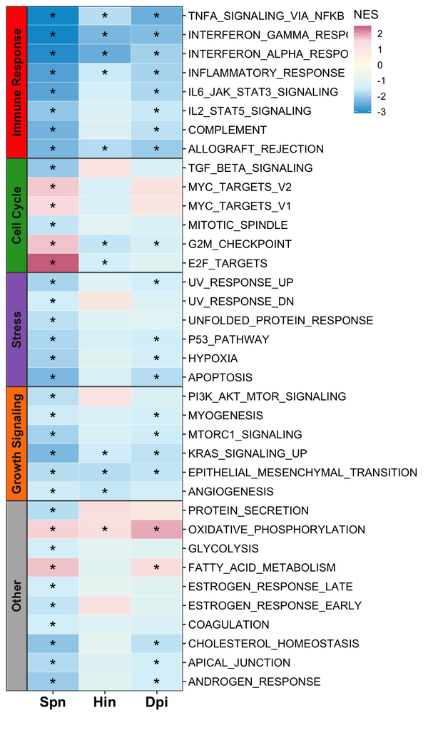

```r
# Define contrasts and nicknames for cleaner labels
multi_list_VirusEffect_diff_vsNB <- c("VirusEffectDiff_Spn", "VirusEffectDiff_Hin", "VirusEffectDiff_Dpi")
contrast_nicknames <- c(VirusEffectDiff_Spn = "Spn", VirusEffectDiff_Hin = "Hin", VirusEffectDiff_Dpi = "Dpi")

# Run multi-contrast GSEA
multi_gsea_VirusEffect_diff_vsNB <- run_multi_contrast_gsea(DESeqData, multi_list_VirusEffect_diff_vsNB, msigdbr_human,
                                                            collection = "H", padj_threshold = 0.05, nes_threshold = 1.5)

# Generate grouped heatmap
multi_gsea_VirusEffect_diff_vsNB_heatmap <- plot_fgsea_grouped_ggplot(multi_gsea_VirusEffect_diff_vsNB,
                                                                      pathway_groups_HALLMARK, category_colors_HALLMARK,
                                                                      padj_threshold = 0.05,
                                                                      title = "GSEA NES: Virus Effect Difference",
                                                                      contrast_nicknames)
multi_gsea_VirusEffect_diff_vsNB_heatmap
```

```r
# Save heatmap and NES values
ggsave(filename = file.path(outputs_folder, "GSEA_VirusEffectDiff_NES_Heatmap.png"),
       plot = multi_gsea_VirusEffect_diff_vsNB_heatmap, width = 6, height = 10, dpi = 300)
saveRDS(multi_gsea_VirusEffect_diff_vsNB_heatmap, file = file.path(outputs_folder, "GSEA_VirusEffectDiff_NES_Heatmap.rds"))

saveRDS(multi_gsea_VirusEffect_diff_vsNB, file = file.path(outputs_folder, "GSEA_VirusEffectDiff_Results.rds"))
write_csv(multi_gsea_VirusEffect_diff_vsNB$combined_df, file.path(outputs_folder, "GSEA_VirusEffectDiff_NES_Values.csv"))
```